# Predicting Chronic Kidney Disease

Michelle Koh

2024-12-12

## Introduction

This is a multivariate dataset that I had found on UC Irvine’s Machine Learning repository, which can be used to predict chronic kidney disease. Chronic kidney disease or CKD is usually identified with kidney damage or an estimated glomerular filtration rate of less than 60 mL/min/1.73 m² - usually consistently lower for 3 or more months.

This dataset contains 400 observations with 25 different variable, including: age, blood pressure, specific gravity, albumin, sugar, red blood cells, pus cell, pus cell clumps, bacteria, blood glucose random, blood urea, serum creatinine, sodium, potassium, hemoglobin, packed cell volume, white blood cell count, red blood cell count, hypertension, diabetes mellitus, coronary artery disease, appetite, pedal edema, anemia, class. All were collected between a 2 month period.

Based the results from our chronic kidney disease dataset, hopefully future chronic kidney disease patients will be identified, sooner the better.

##### Analysis Objectives

- To perform descriptive statistics and identify trends among the different variables and observations.
- Afterwards, visualize the trends by creating figures that is easier to follow.

```
## here() starts at /Users/michellekoh/Desktop/data550/Chronic-Kidney-Final-Project
```

```
## here() starts at /Users/michellekoh/Desktop/data550/Chronic-Kidney-Final-Project
```

## Descriptive tables

##### Here we have two different descriptive tables for better understanding of the dataset

The first summary table shows us the prevalence for character variables stratified by CKD and NON-CKD patients in this dataset. The prevalence of certain variables correctly show the difference in abnormality of the collected variables.

This second table shows the summary table for numeric variables also stratified by CKD or Non-CKD patients. Here, you can see the clear discrepancies in results for those with CKD and those without CKD.

```r
ckd_data <- read.csv(
  file = here::here("data/chronic_kidney_disease_data.csv")
)

head(ckd_data)
```

```
##   age bp    sg al su    rbc       pc        pcc         ba bgr bu  sc sod pot
## 1  48 80 1.020  1  0          normal notpresent notpresent 121 36 1.2  NA  NA
## 2   7 50 1.020  4  0          normal notpresent notpresent  NA 18 0.8  NA  NA
## 3  62 80 1.010  2  3 normal   normal notpresent notpresent 423 53 1.8  NA  NA
## 4  48 70 1.005  4  0 normal abnormal    present notpresent 117 56 3.8 111 2.5
## 5  51 80 1.010  2  0 normal   normal notpresent notpresent 106 26 1.4  NA  NA
## 6  60 90 1.015  3  0                 notpresent notpresent  74 25 1.1 142 3.2
##   hemo pcv wbcc rbcc htn  dm cad appet  pe ane target
## 1 15.4  44 7800  5.2 yes yes  no  good  no  no    ckd
## 2 11.3  38 6000   NA  no  no  no  good  no  no    ckd
## 3  9.6  31 7500   NA  no yes  no  poor  no yes    ckd
## 4 11.2  32 6700  3.9 yes  no  no  poor yes yes    ckd
## 5 11.6  35 7300  4.6  no  no  no  good  no  no    ckd
## 6 12.2  39 7800  4.4 yes yes  no  good yes  no    ckd
```

```r
#first table
characteristics_summary_kidney <- readRDS(
  here::here("output/characteristics_summary_kidney.rds")
)

characteristics_summary_kidney
```

| **Characteristic** | **ckd** N = 248<sup>1</sup> | **notckd** N = 150<sup>1</sup> |
| --- | --- | --- |
| Red Blood Cells |  |  |
|  | 142 (57%) | 9 (6.0%) |
| abnormal | 47 (19%) | 0 (0%) |
| normal | 59 (24%) | 141 (94%) |
| Pus Cell |  |  |
|  | 55 (22%) | 9 (6.0%) |
| abnormal | 75 (30%) | 0 (0%) |
| normal | 118 (48%) | 141 (94%) |
| Pus Cell Clumps |  |  |
|  | 0 (0%) | 4 (2.7%) |
| notpresent | 207 (83%) | 146 (97%) |
| present | 41 (17%) | 0 (0%) |
| Bacteria |  |  |
|  | 0 (0%) | 4 (2.7%) |
| notpresent | 226 (91%) | 146 (97%) |
| present | 22 (8.9%) | 0 (0%) |
| Hypertension |  |  |
|  | 0 (0%) | 2 (1.3%) |
| no | 103 (42%) | 148 (99%) |
| yes | 145 (58%) | 0 (0%) |
| Diabetes |  |  |
|  | 0 (0%) | 2 (1.3%) |
| no | 1 (0.4%) | 0 (0%) |
| no | 112 (45%) | 148 (99%) |
| yes | 135 (54%) | 0 (0%) |
| Coronary Artery Disease |  |  |
|  | 0 (0%) | 2 (1.3%) |
| no | 214 (86%) | 148 (99%) |
| yes | 34 (14%) | 0 (0%) |
| Appetite |  |  |
|  | 0 (0%) | 1 (0.7%) |
| good | 168 (68%) | 149 (99%) |
| poor | 80 (32%) | 0 (0%) |
| Pedal Edema |  |  |
|  | 0 (0%) | 1 (0.7%) |
| no | 172 (69%) | 149 (99%) |
| yes | 76 (31%) | 0 (0%) |
| Anemia |  |  |
|  | 0 (0%) | 1 (0.7%) |
| no | 189 (76%) | 149 (99%) |
| yes | 59 (24%) | 0 (0%) |

<sup>1</sup> n (%)

```r
#second table
numeric_summary <- readRDS(
  here::here("output/numeric_summary.rds")
)

numeric_summary
```

| **Characteristic** | **ckd** N = 248<sup>1</sup> | **notckd** N = 150<sup>1</sup> |
| --- | --- | --- |
| Age | 59 (47, 66) | 46 (34, 58) |
| Blood Pressure (mm/Hg) | 80 (70, 90) | 70 (60, 80) |
| Specific Gravity |  |  |
| 1.005 | 7 (3.4%) | 0 (0%) |
| 1.01 | 83 (40%) | 0 (0%) |
| 1.015 | 75 (36%) | 0 (0%) |
| 1.02 | 31 (15%) | 75 (52%) |
| 1.025 | 11 (5.3%) | 70 (48%) |
| Blood Glucose Random (mgs/dl) | 144 (106, 220) | 108 (94, 124) |
| Blood Urea (mgs/dl) | 53 (32, 94) | 33 (24, 44) |
| Serum Creatinine (mgs/dl) | 2.3 (1.4, 4.6) | 0.9 (0.6, 1.1) |
| Sodium (mEq/L) | 136 (132, 139) | 141 (138, 146) |
| Potassium (mEq/L) | 4.30 (3.80, 4.90) | 4.50 (3.70, 4.90) |
| Hemoglobin (gms) | 10.90 (9.40, 12.10) | 15.00 (14.10, 16.20) |
| Packed Cell Volume | 33 (29, 37) | 46 (43, 50) |
| White Blood Cell Count | 8,800 (6,700, 10,700) | 7,500 (6,300, 9,300) |

<sup>1</sup> Median (Q1, Q3); n (%)

## Graphs for some visualization!!!!

Although the heatmap doesn’t specifically pinpoint what is happening in this dataset, we can use the results to further investigate and formulate more questions.

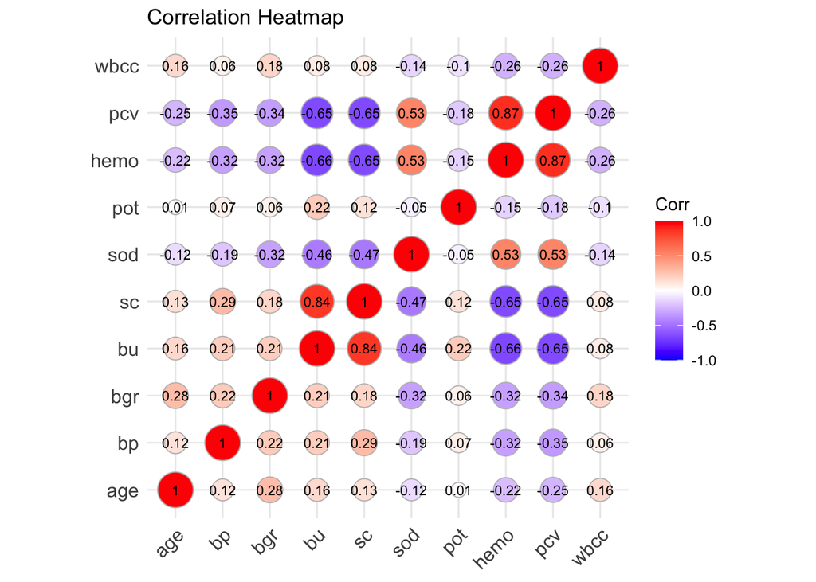

```r
#correlation heat map
ckd_plot_corr <- readRDS(
  here::here("output/ckd_plot_corr.rds")
)

ckd_plot_corr
```

##### Citations:

Rubini, L., Soundarapandian, P., & Eswaran, P. (2015). Chronic Kidney Disease [Dataset]. UCI Machine Learning Repository. https://doi.org/10.24432/C5G020.

Vaidya SR, Aeddula NR. Chronic Kidney Disease. [Updated 2024 Jul 31]. In: StatPearls [Internet]. Treasure Island (FL): StatPearls Publishing; 2024 Jan-. Available from: https://www.ncbi.nlm.nih.gov/books/NBK535404/